# Reproducible Research: Peer Assessment 1

### Load tidyverse and data.table packages

```r
library(tidyverse)
library(data.table)
```

## Loading and preprocessing the data

**Load the data in R. Environment**

```r
unzip("./activity.zip")
Activity_Data <- read.csv("./activity.csv")
```

**Convert dataframe to a Tibble**

```r
Activity_Data <- as_tibble(Activity_Data)
```

**Initial data exploration**

```r
summary(Activity_Data)
```

```
##      steps            date              interval
##  Min.   :  0.00   Length:17568       Min.   :   0.0
##  1st Qu.:  0.00   Class :character   1st Qu.: 588.8
##  Median :  0.00   Mode  :character   Median :1177.5
##  Mean   : 37.38                      Mean   :1177.5
##  3rd Qu.: 12.00                      3rd Qu.:1766.2
##  Max.   :806.00                      Max.   :2355.0
##  NA's   :2304
```

## What is mean total number of steps taken per day?

**Calculate the total number of steps taken per day**

```r
Total_Steps_per_Day <- aggregate(steps ~ date, Activity_Data, sum, na.rm=TRUE)
```

**Make a histogram of the total number of steps taken each day**

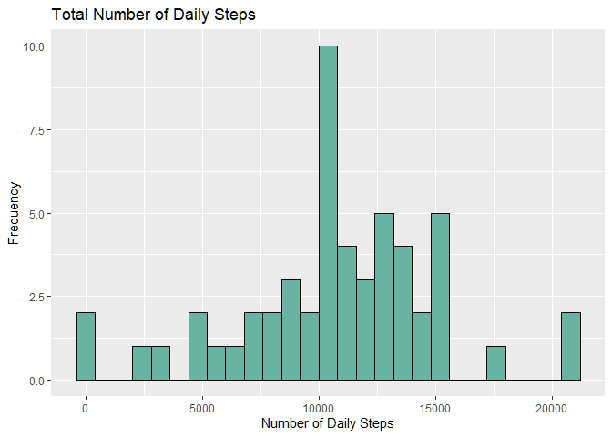

```r
ggplot(Total_Steps_per_Day, aes(steps)) +
  geom_histogram(color ="#000000", fill="#69b3a2", binwidth = 800) +
  labs(x = "Number of Daily Steps", y = "Frequency", title = "Total Number of Daily Steps")
```

**Calculate and report the mean and median of the total number of steps taken per day**

Mean:

```r
mean(Total_Steps_per_Day$steps)
```

```
## [1] 10766.19
```

Median:

```r
median(Total_Steps_per_Day$steps)
```

```
## [1] 10765
```

## What is the average daily activity pattern?

**Make a time series plot of the 5-minute interval and the average number of steps taken, averaged across all days**

```r
Average_Steps_per_Day <- aggregate(Activity_Data$steps, by = list(Activity_Data$interval), FUN = mean, na.rm = TRUE)
```

```r
names(Average_Steps_per_Day) <- c("Interval", "Mean")
```

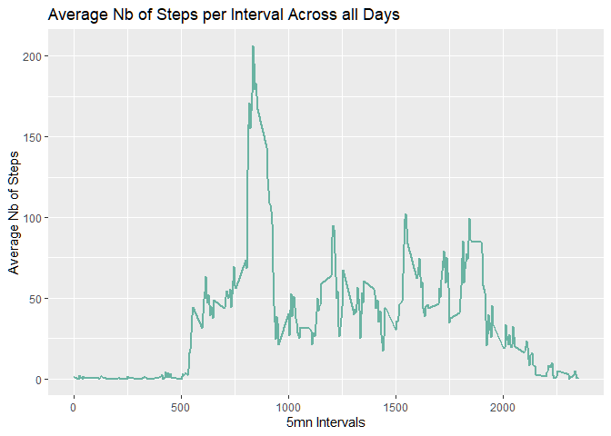

```r
ggplot(Average_Steps_per_Day, aes(x = Interval, y = Mean)) +
  geom_line(color = "#69b3a2", size = 0.8) +
  labs(x = "5mn Intervals", y = "Average Nb of Steps", title = "Average Nb of Steps per Interval Across all Days")
```

**Which 5-minute interval, on average across all the days in the dataset, contains the maximum number of steps?**

```r
Average_Steps_per_Day[which.max(Average_Steps_per_Day$Mean), ]$Interval
```

```
## [1] 835
```

## Imputing missing values

**Calculate and report the total number of missing values in the dataset**

```r
sum(is.na(Activity_Data$steps))
```

```
## [1] 2304
```

**Devise a strategy for filling in all of the missing values in the dataset** We will fill the missing data with the mean for the same interval. Let’s define a function to do so

```r
NoNAs <- Average_Steps_per_Day$Mean[match(Activity_Data$interval, Average_Steps_per_Day$Interval)]
```

**Create a new dataset that is equal to the original dataset but with the missing data filled in**

Let’s first create a new general dataset with NAs filled with “mean per interval”

```r
Activity_Data_Filled <- transform(Activity_Data, steps = ifelse(is.na(Activity_Data$steps), yes = NoNAs, no = Activity_Data$steps))
```

Now create a new Total_Steps dataframe with NAs filled with “mean per interval”

```r
Total_Steps_per_Day_Filled <- aggregate(steps ~ date, Activity_Data_Filled, sum)
```

**Make a histogram of the total number of steps taken each day**

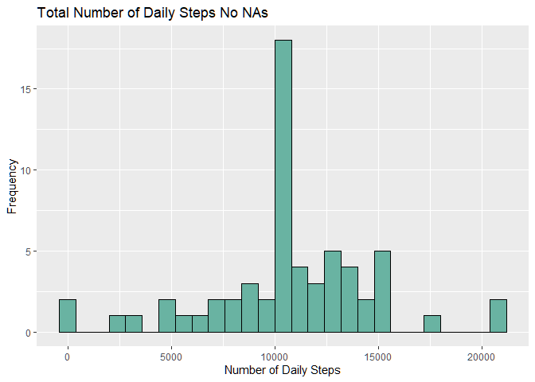

```r
ggplot(Total_Steps_per_Day_Filled, aes(steps)) +
  geom_histogram(color ="#000000", fill="#69b3a2", binwidth = 800) +
  labs(x = "Number of Daily Steps", y = "Frequency", title = "Total Number of Daily Steps No NAs")
```

**Calculate and report the mean and median total number of steps taken per day** mean:

```r
mean(Total_Steps_per_Day_Filled$steps)
```

```
## [1] 10766.19
```

Median:

```r
median(Total_Steps_per_Day_Filled$steps)
```

```
## [1] 10766.19
```

## Are there differences in activity patterns between weekdays and weekends?

**Create a new factor variable in the dataset with two levels – “weekday” and “weekend” indicating whether a given date is a weekday or weekend day**

```r
Activity_Data_Dates <- mutate(Activity_Data, Day_of_Week = weekdays(as.POSIXct(date, format = "%Y-%m-%d")))
```

```r
Activity_Data_Dates <- Activity_Data_Dates %>%
  mutate ("weekday/weekend" =
        ifelse(Day_of_Week %in% c("lundi", "mardi", "mercredi", "jeudi", "vendredi"), "weekday",
        ifelse( Day_of_Week %in% c("samedi", "dimanche"), "weekend", no = FALSE)))
Activity_Data_Dates$`weekday/weekend` <- as.factor(Activity_Data_Dates$`weekday/weekend`)
```

```r
NoNAs2 <- filter(Activity_Data_Dates, (!is.na(steps & steps==median(steps)))) %>%
                    head(n=1) %>%
                    select(steps) %>%
                    as.numeric()
```

```r
Activity_Data_Dates <- mutate(Activity_Data_Dates, steps = tidyr ::replace_na(steps, NoNAs2))
```

```r
Tidy_Activity_Data_Dates <- group_by(Activity_Data_Dates, interval, `weekday/weekend` ) %>%
  summarize(mean = mean(steps))
```

**Make a panel plot containing a time series plot of the 5-minute interval and the average number of steps taken, averaged across all weekday days or weekend days**

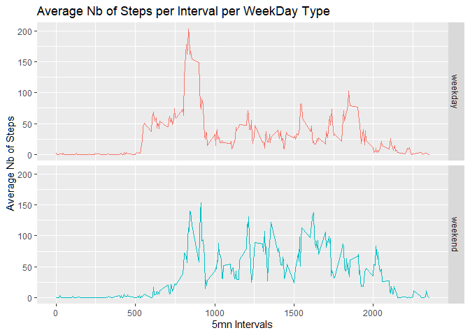

```r
ggplot(Tidy_Activity_Data_Dates, aes(x = interval, y = mean, color = `weekday/weekend`)) +
  geom_line(size = 0.7) +
  labs(x = "5mn Intervals", y = "Average Nb of Steps", title = "Average Nb of Steps per Interval per WeekDay Type") +
  facet_grid(rows = vars(`weekday/weekend`)) +
  theme(legend.position = "none")
```

**Are there differences in activity patterns between weekdays and weekends?** Not surprisingly, more activity is recorded early morning in the week days than during week-ends. Activity trend seems to decrease and stabilize after the early morning peak during week days while , during the week-ends, activity trend looks more regular while starting a bit later and ending a bit later than during week days.